# R Notebook

# 1. Décrire la situation statistique du jeu de données decathlon.csv

41 individus : des sportifs  
12 variables quantitatives  
1 variable quali Competition à deux modalité : Jo et Decastar

```r
df<-read.csv(file="decathlon.csv",head=TRUE, sep=";")
head(df)
```

|  | X | X100m | Longueur | Poids | Hauteur | X400m | X110m.H | Disque | Perche | Javelot | X1500m | Classement | Points | Competition |
| --- | --- | --- | --- | --- | --- | --- | --- | --- | --- | --- | --- | --- | --- | --- |
| 1 | Sebrle | 10.85 | 7.84 | 16.36 | 2.12 | 48.36 | 14.05 | 48.72 | 5.0 | 70.52 | 280.01 | 1 | 8893 | JO |
| 2 | Clay | 10.44 | 7.96 | 15.23 | 2.06 | 49.19 | 14.13 | 50.11 | 4.9 | 69.71 | 282.00 | 2 | 8820 | JO |
| 3 | Karpov | 10.50 | 7.81 | 15.93 | 2.09 | 46.81 | 13.97 | 51.65 | 4.6 | 55.54 | 278.11 | 3 | 8725 | JO |
| 4 | Macey | 10.89 | 7.47 | 15.73 | 2.15 | 48.97 | 14.56 | 48.34 | 4.4 | 58.46 | 265.42 | 4 | 8414 | JO |
| 5 | Warners | 10.62 | 7.74 | 14.48 | 1.97 | 47.97 | 14.01 | 43.73 | 4.9 | 55.39 | 278.05 | 5 | 8343 | JO |
| 6 | Zsivoczky | 10.91 | 7.14 | 15.31 | 2.12 | 49.40 | 14.95 | 45.62 | 4.7 | 63.45 | 269.54 | 6 | 8287 | JO |

# 2. Réaliser une analyse statistique univariée pour l’ensemble des variables quantitatives.

## Resumé matriciel

```r
summary(df)
```

```
      X                 X100m          Longueur        Poids          Hauteur          X400m          X110m.H          Disque          Perche
 Length:41          Min.   :10.44   Min.   :6.61   Min.   :12.68   Min.   :1.850   Min.   :46.81   Min.   :13.97   Min.   :37.92   Min.   :4.200
 Class :character   1st Qu.:10.85   1st Qu.:7.03   1st Qu.:13.88   1st Qu.:1.920   1st Qu.:48.93   1st Qu.:14.21   1st Qu.:41.90   1st Qu.:4.500
 Mode  :character   Median :10.98   Median :7.30   Median :14.57   Median :1.950   Median :49.40   Median :14.48   Median :44.41   Median :4.800
                    Mean   :11.00   Mean   :7.26   Mean   :14.48   Mean   :1.977   Mean   :49.62   Mean   :14.61   Mean   :44.33   Mean   :4.762
                    3rd Qu.:11.14   3rd Qu.:7.48   3rd Qu.:14.97   3rd Qu.:2.040   3rd Qu.:50.30   3rd Qu.:14.98   3rd Qu.:46.07   3rd Qu.:4.920
                    Max.   :11.64   Max.   :7.96   Max.   :16.36   Max.   :2.150   Max.   :53.20   Max.   :15.67   Max.   :51.65   Max.   :5.400
    Javelot          X1500m        Classement        Points     Competition
 Min.   :50.31   Min.   :262.1   Min.   : 1.00   Min.   :7313   Length:41
 1st Qu.:55.27   1st Qu.:271.0   1st Qu.: 6.00   1st Qu.:7802   Class :character
 Median :58.36   Median :278.1   Median :11.00   Median :8021   Mode  :character
 Mean   :58.32   Mean   :279.0   Mean   :12.12   Mean   :8005
 3rd Qu.:60.89   3rd Qu.:285.1   3rd Qu.:18.00   3rd Qu.:8122
 Max.   :70.52   Max.   :317.0   Max.   :28.00   Max.   :8893
```

‘sapply(df, is.numeric)’ retourne un vecteur logique où chaque élément est TRUE si la colonne est numérique, sinon FALSE

```r
Xquanti <- df[, sapply(df, is.numeric)]
Xquanti
```

| X100m | Longueur | Poids | Hauteur | X400m | X110m.H | Disque | Perche | Javelot | X1500m | Classement | Points |
| --- | --- | --- | --- | --- | --- | --- | --- | --- | --- | --- | --- |
| 10.85 | 7.84 | 16.36 | 2.12 | 48.36 | 14.05 | 48.72 | 5.00 | 70.52 | 280.01 | 1 | 8893 |
| 10.44 | 7.96 | 15.23 | 2.06 | 49.19 | 14.13 | 50.11 | 4.90 | 69.71 | 282.00 | 2 | 8820 |
| 10.50 | 7.81 | 15.93 | 2.09 | 46.81 | 13.97 | 51.65 | 4.60 | 55.54 | 278.11 | 3 | 8725 |
| 10.89 | 7.47 | 15.73 | 2.15 | 48.97 | 14.56 | 48.34 | 4.40 | 58.46 | 265.42 | 4 | 8414 |
| 10.62 | 7.74 | 14.48 | 1.97 | 47.97 | 14.01 | 43.73 | 4.90 | 55.39 | 278.05 | 5 | 8343 |
| 10.91 | 7.14 | 15.31 | 2.12 | 49.40 | 14.95 | 45.62 | 4.70 | 63.45 | 269.54 | 6 | 8287 |
| 10.97 | 7.19 | 14.65 | 2.03 | 48.73 | 14.25 | 44.72 | 4.80 | 57.76 | 264.35 | 7 | 8237 |
| 10.80 | 7.53 | 14.26 | 1.88 | 48.81 | 14.80 | 42.05 | 5.40 | 61.33 | 276.33 | 8 | 8235 |
| 10.69 | 7.48 | 14.80 | 2.12 | 49.13 | 14.17 | 44.75 | 4.40 | 55.27 | 276.31 | 9 | 8225 |
| 10.98 | 7.49 | 14.01 | 1.94 | 49.76 | 14.25 | 42.43 | 5.10 | 56.32 | 273.56 | 10 | 8102 |

[output cut: 31 more lines]

### Variance

#### Matrice de variance-covariance

Cov(U,V)=0 et U, V sont des variables gaussiennes donc $U \perp\!\!\!\perp V$.

$$Cov(U,V)=0 \Rightarrow U
\perp\!\!\!\perp V$$

> *QAP : D’après la propriété ci-dessus je devrais obtenir une matrice de variance covariance diagonal avec des valeur proche de 0 à l’extérieur des diagonale : poruquoi n’est ce pas le cas ?*

```r
mat_var_cov <- var(Xquanti)
mat_var_cov
```

```
                   X100m   Longueur        Poids      Hauteur         X400m       X110m.H      Disque        Perche      Javelot        X1500m    Classement
X100m        0.069181098 -0.0498225  -0.07730085 -0.005761341    0.15785018  7.195921e-02  -0.1969763 -0.0060351220  -0.20026933   -0.18589774     0.6179939
Longueur    -0.049822500  0.1001100   0.04781500  0.008292500   -0.21972500 -7.544500e-02   0.2076700  0.0179450000   0.18289750   -0.12441750    -1.5135000
Poids       -0.077300854  0.0478150   0.67968122  0.035875488   -0.13164098 -9.786744e-02   1.7147843  0.0140223171   1.49208476    1.11445963    -2.4153841
Hauteur     -0.005761341  0.0082925   0.03587549  0.007912195   -0.01928439 -1.188848e-02   0.1109357 -0.0038620732   0.07379640   -0.04662415    -0.3471037
X400m        0.157850183 -0.2197250  -0.13164098 -0.019284390    1.33044878  2.982070e-01  -0.4592790 -0.0254258537   0.02356220    5.49495579     5.1344573
X110m.H      0.071959207 -0.0754450  -0.09786744 -0.011888476    0.29820695  2.225849e-01  -0.5198437 -0.0003546341   0.01991049    0.20674573     1.6405183
Disque      -0.196976280  0.2076700   1.71478433  0.110935732   -0.45927896 -5.198437e-01  11.4098352 -0.1409240244   2.57427463   10.17995195   -10.4087012
Perche      -0.006035122  0.0179450   0.01402232 -0.003862073   -0.02542585 -3.546341e-04  -0.1409240  0.0772839024  -0.04025646    0.80300780    -0.7053049
Javelot     -0.200269329  0.1828975   1.49208476  0.073796402    0.02356220  1.991049e-02   2.5742746 -0.0402564634  23.29819305  -10.16419043    -7.9540732
X1500m      -0.185897744 -0.1244175   1.11445963 -0.046624146    5.49495579  2.067457e-01  10.1799520  0.8030078049 -10.16419043  136.26470061     8.3101402
Classement   0.617993902 -1.5135000  -2.41538415 -0.347103659    5.13445732  1.640518e+00 -10.4087012 -0.7053048780  -7.95407317    8.31014024    62.7097561
Points     -61.622268293 78.5547500 177.09434756 17.563689024 -263.39087805 -1.041019e+02 559.9691463 18.7925853659 698.06028049 -776.76207927 -2004.1707317
                 Points
X100m         -61.62227
Longueur       78.55475
Poids         177.09435
Hauteur        17.56369
X400m        -263.39088
X110m.H      -104.10195
Disque        559.96915
Perche         18.79259
Javelot       698.06028
X1500m       -776.76208
Classement  -2004.17073
Points     117227.58780
```

```r
dim(mat_var_cov)
```

```
[1] 12 12
```

#### Variance par colonne

La fonction `apply` permet d’appliquer une fonction à chaque colonne (ou ligne) d’un dataframe ou d’une matrice. Syntaxe : apply(X, MARGIN, FUN)

- X : L’objet (dataframe ou matrice)

- MARGIN : 1 pour les lignes, 2 pour les colonnes

- FUN : La fonction à appliquer (ici, ‘var’ pour la variance)

```r
apply(Xquanti, 2, var)
```

```
       X100m     Longueur        Poids      Hauteur        X400m      X110m.H       Disque       Perche      Javelot       X1500m   Classement       Points
6.918110e-02 1.001100e-01 6.796812e-01 7.912195e-03 1.330449e+00 2.225849e-01 1.140984e+01 7.728390e-02 2.329819e+01 1.362647e+02 6.270976e+01 1.172276e+05
```

# 2 bis. Variable qualitatives.

```r
Xquali <- df[, sapply(df, Negate(is.numeric))]
Xquali
```

| X | Competition |
| --- | --- |
| Sebrle | JO |
| Clay | JO |
| Karpov | JO |
| Macey | JO |
| Warners | JO |
| Zsivoczky | JO |
| Hernu | JO |
| Nool | JO |
| Bernard | JO |
| Schwarzl | JO |

[output cut: 31 more lines]

### Tableau de contingence

> *QAP : Il faut faire un tableau de contingence avec quel variable ?*
- En nombre d’occurence
- en frequence `` table(Xquali)/lenght(table(``Xquali``)) ``

```r
table(Xquali)
```

```
             Competition
X             Decastar JO
  Averyanov          0  1
  Barras             0  1
  BARRAS             1  0
  Bernard            0  1
  BERNARD            1  0
  BOURGUIGNON        1  0
  Casarsa            0  1
  Clay               0  1
  CLAY               1  0
  Drews              0  1
  Gomez              0  1
  Hernu              0  1
  HERNU              1  0
  Karlivans          0  1
  Karpov             0  1
  KARPOV             1  0
  Korkizoglou        0  1
  Lorenzo            0  1
  Macey              0  1
  MARTINEAU          1  0
  McMULLEN           1  0
  Nool               0  1
  NOOL               1  0
  Ojaniemi           0  1
  Parkhomenko        0  1
  Pogorelov          0  1
  Qi                 0  1
  Schoenbeck         0  1
  Schwarzl           0  1
  Sebrle             0  1
  SEBRLE             1  0
  Smirnov            0  1
  Smith              0  1
  Terek              0  1
  Turi               0  1
  Uldal              0  1
  Warners            0  1
  WARNERS            1  0
  YURKOV             1  0
  Zsivoczky          0  1
  ZSIVOCZKY          1  0
```

## Resumé graphique

### Boxplot *(boite à moustaches)*

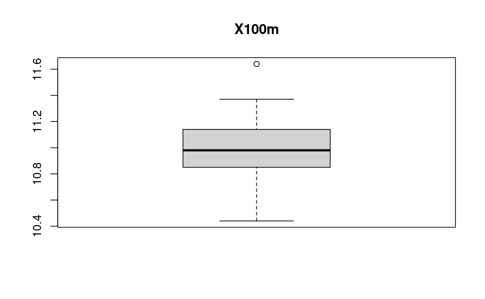

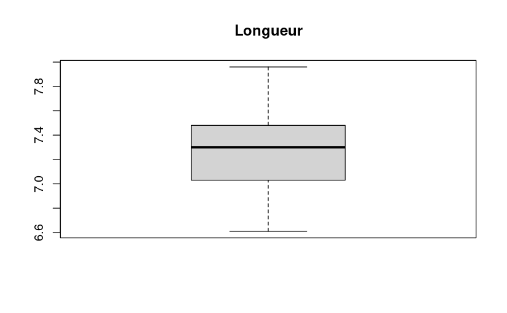

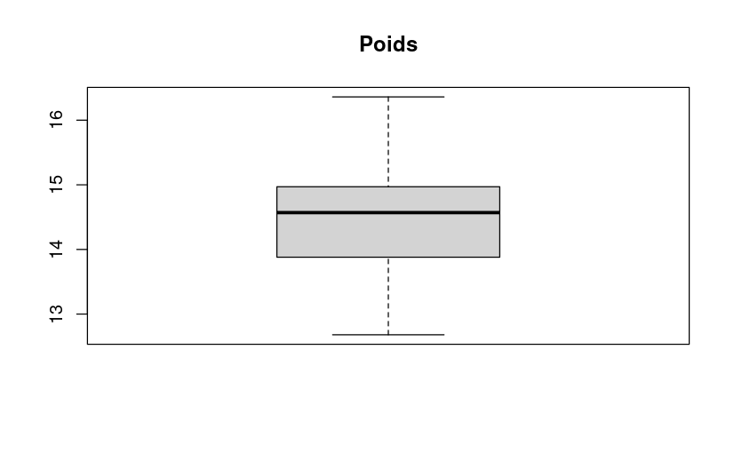

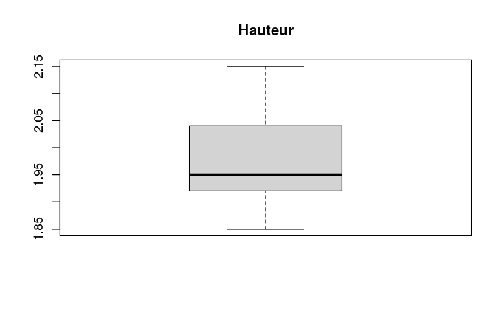

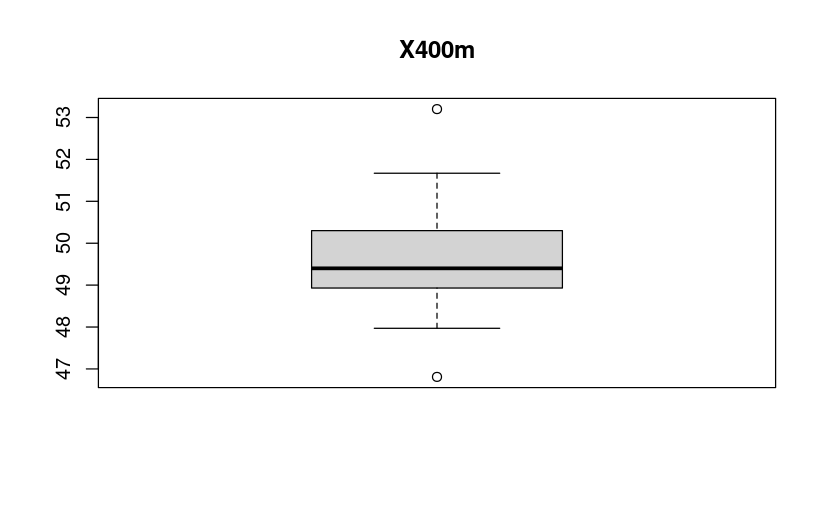

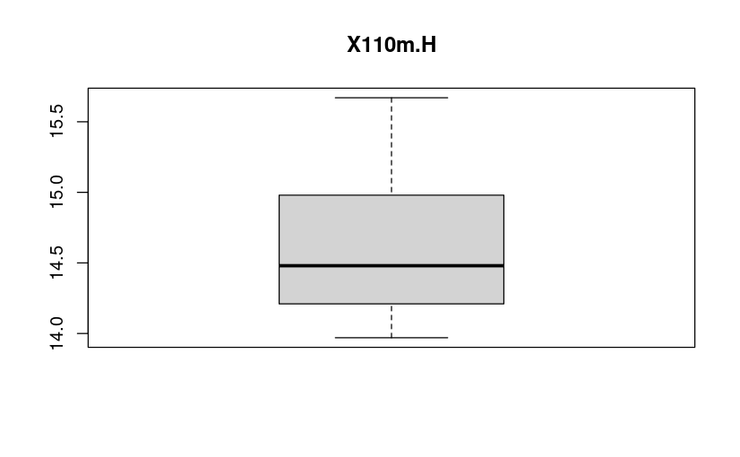

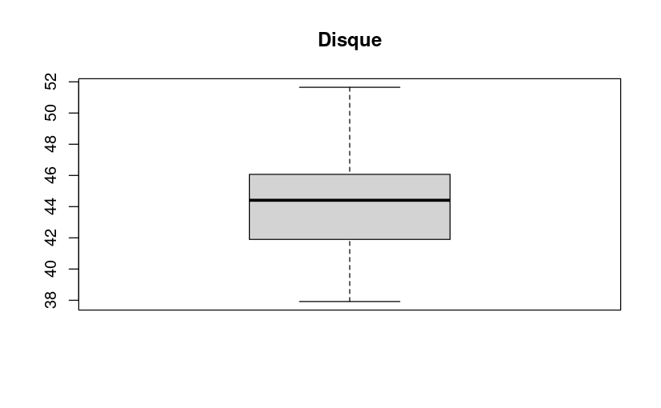

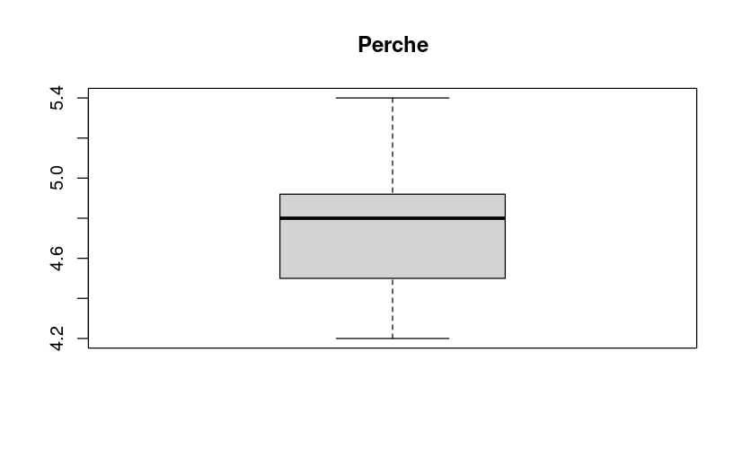

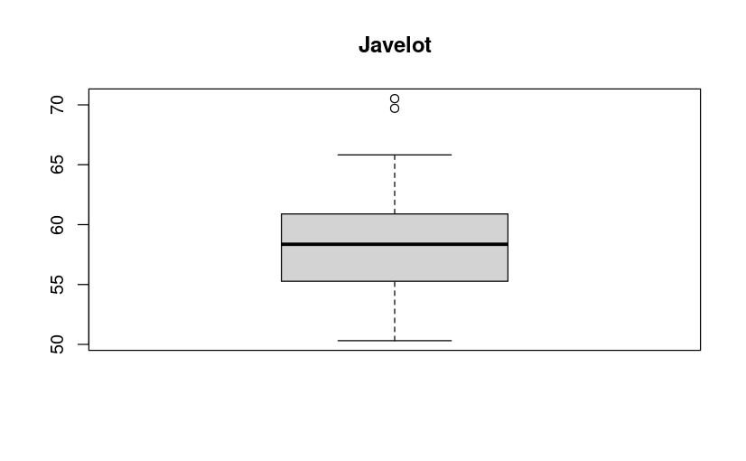

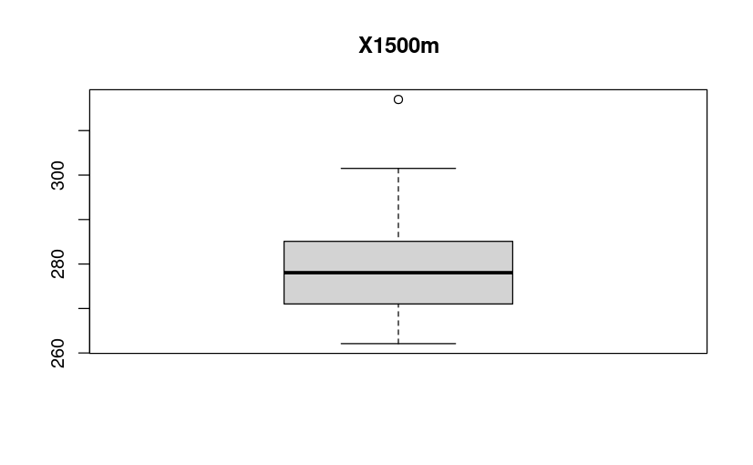

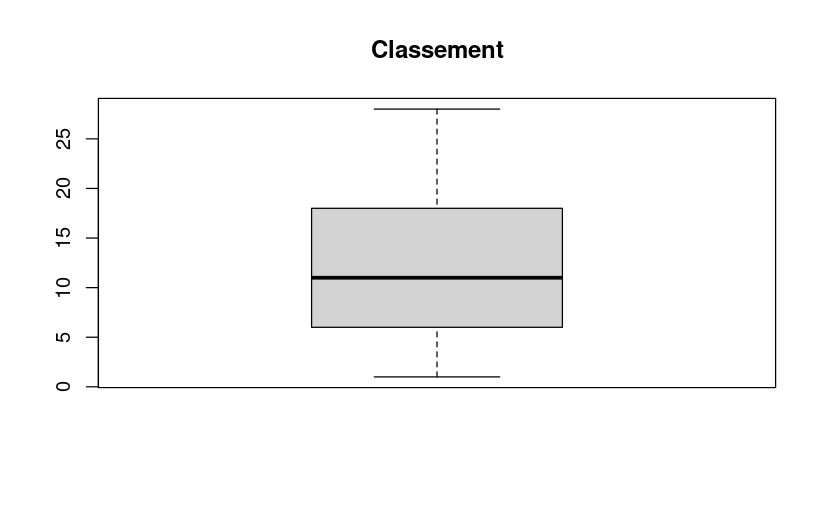

```r
i <- c(1:12)
for (j in i) {
  boxplot(Xquanti[, j], main = colnames(Xquanti)[j])  # Affiche le titre avec le nom de la colonne
}
```

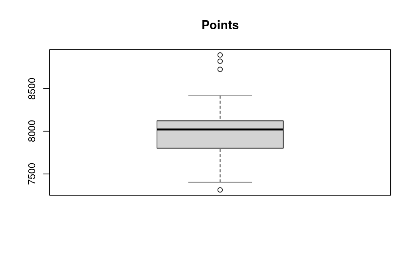

```r
NA
```

### Histogram

densité gaussienne

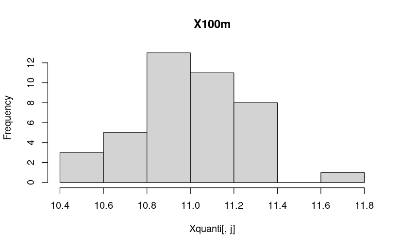

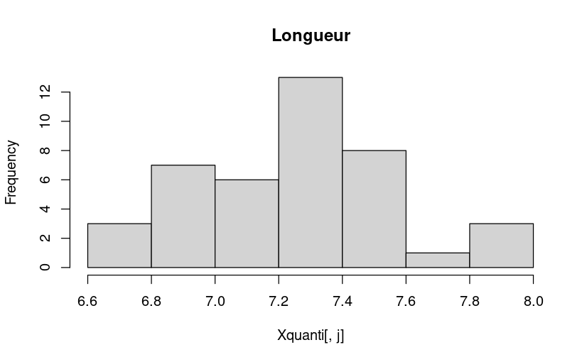

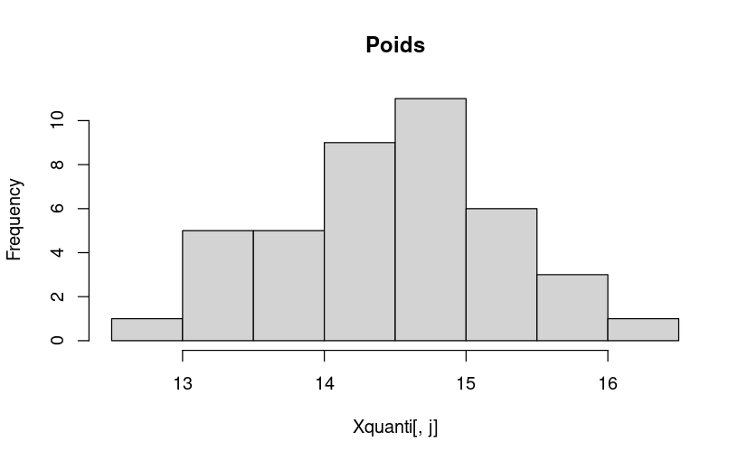

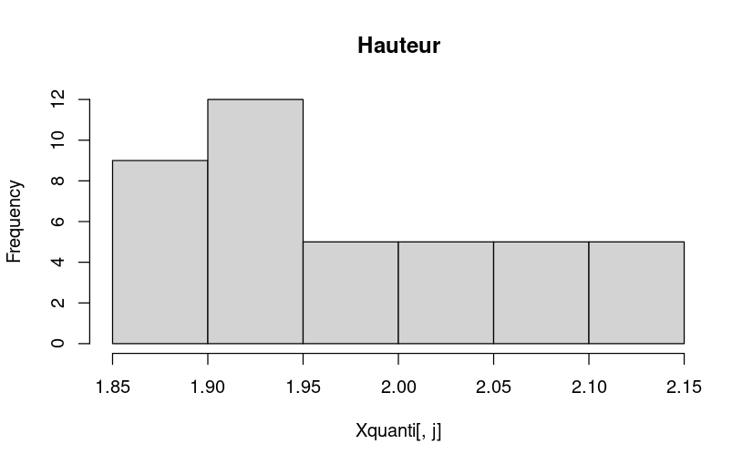

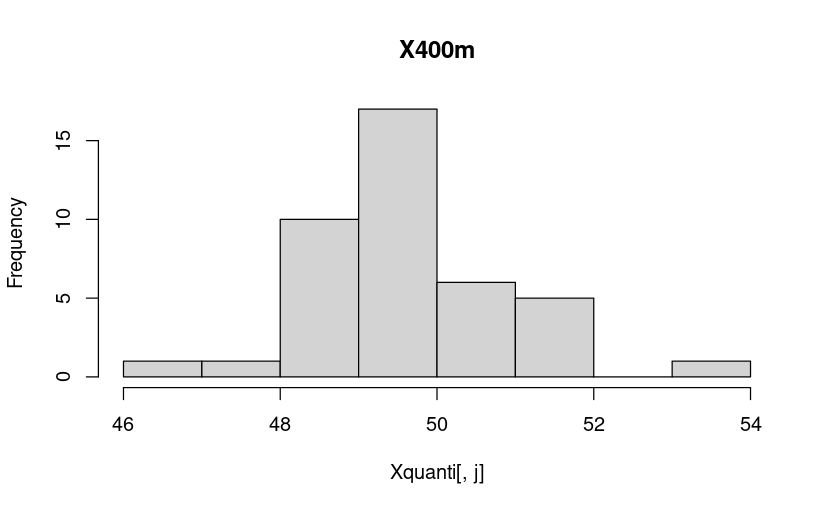

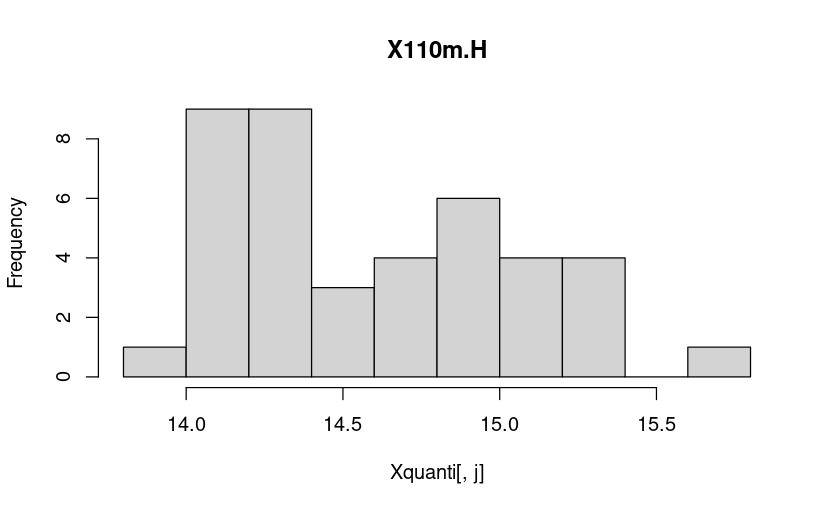

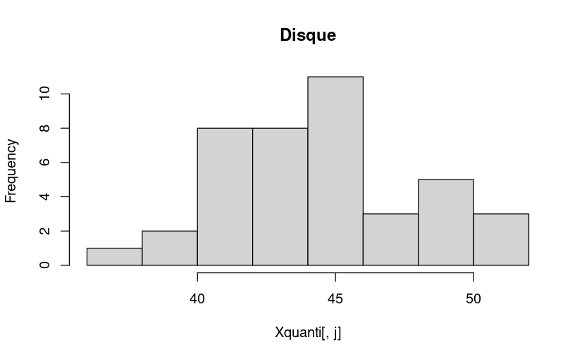

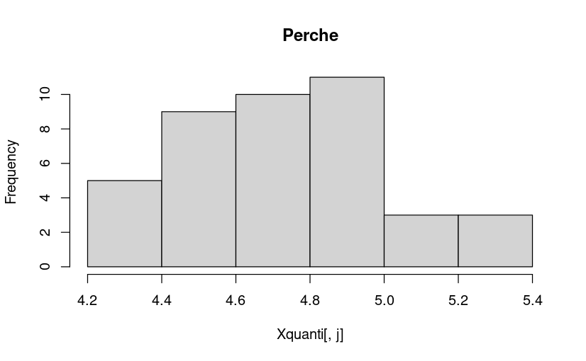

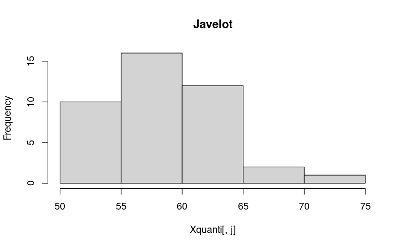

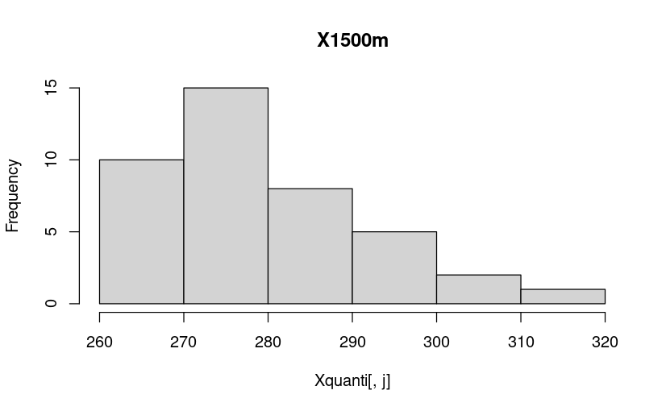

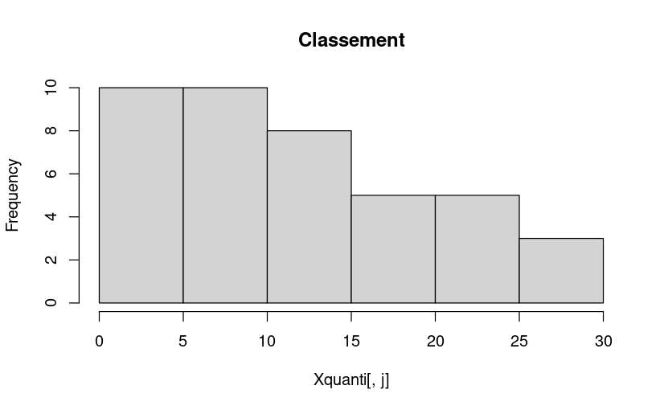

```r
for (j in i) {
  hist(Xquanti[, j], main = colnames(Xquanti)[j])  # Affiche le titre avec le nom de la colonne
}
```

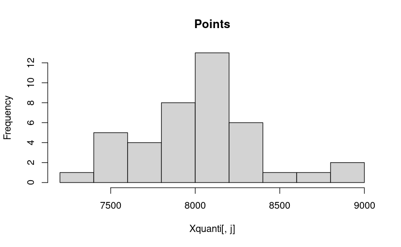

```r
NA
```